# Week 7 Tasks Solutions

# Further Tasks

## Yanny or Laurel?

This auditory illusion first appeared on the internet in May 2018. An explanation of why people hear different things can be found in this [short video](https://www.youtube.com/watch?v=yDiXQl7grPQ), just one of many internet sources discussing the phenomenon. The main reason behind the difference appears to be that as we age we lose the ability to hear certain sounds. To see if we could find evidence of such an age effect, we asked students and staff at the School of Mathematics and Statistics at the University of Glasgow to fill out a survey on what they hear. Below you can see summaries of the responses.

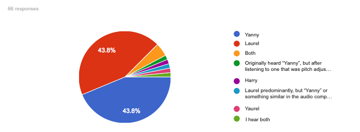

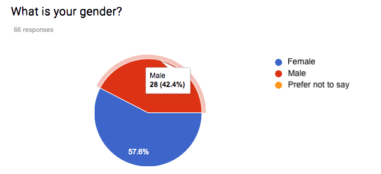

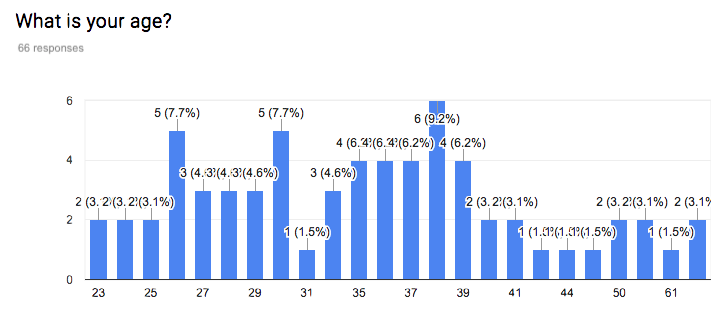

The proportions hearing `Yanny` and `Laurel` are very similar to each other, and there are some respondents who hear both or even something completely different. This may be because people do not listen to the audio file using the same device, something we couldn’t control for in the survey. Ignoring the responses other than `Yanny` or `Laurel`, we have 53 observations.

Download the data (`yanny.csv`) from Moodle and fit a logistic regression model with `hear` as the binary response variable, and `age` and `gender` as the explanatory variables. What are your findings?

**Solution**

```r
yanny <- read_csv("yanny.csv")
yanny <- yanny %>%
          select(hear, gender, age)
yanny$hear <- as.factor(yanny$hear)
yanny$gender <- as.factor(yanny$gender)
```

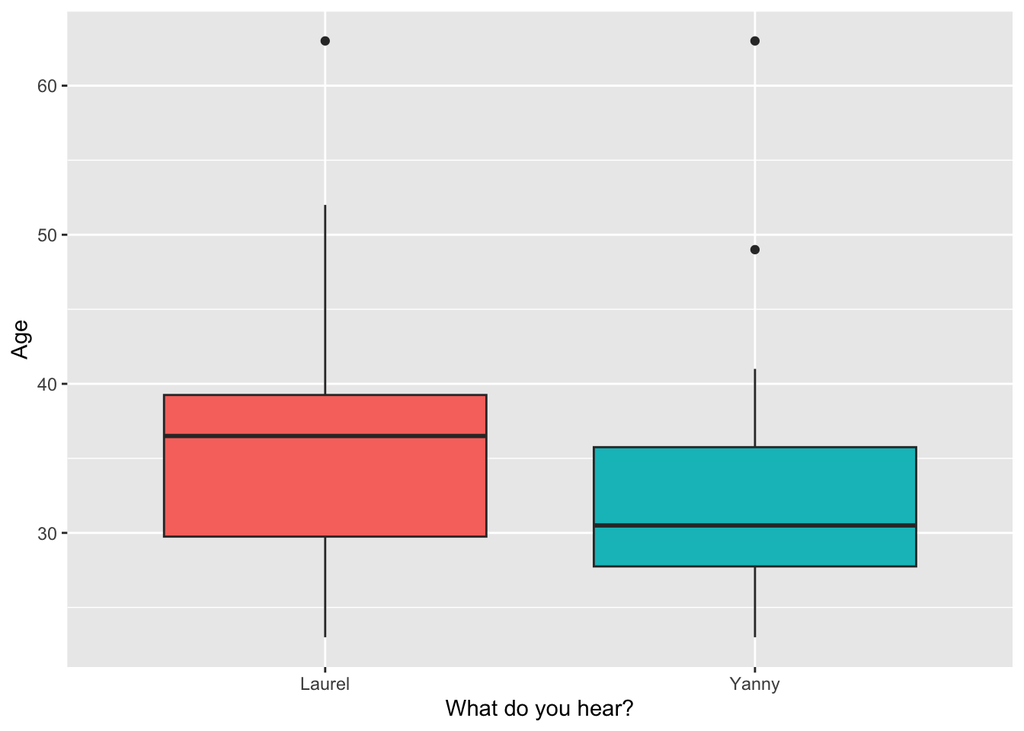

Hearing Yanny/Laurel by age.

```r
ggplot(data = yanny, aes(x = hear, y = age, fill = hear)) +
  geom_boxplot() +
  labs(x = "What do you hear?", y = "Age") +
  theme(legend.position = "none")
```

We see in the boxplot that the people who hear `Yanny` are, on average, younger, however there is some overlap in the IQR’s.

```r
yanny %>%
  tabyl(gender, hear) %>%
  adorn_percentages() %>%
  adorn_pct_formatting() %>%
  adorn_ns() # To show original counts
```

```
 gender     Laurel      Yanny
 Female 50.0% (14) 50.0% (14)
   Male 56.0% (14) 44.0% (11)
```

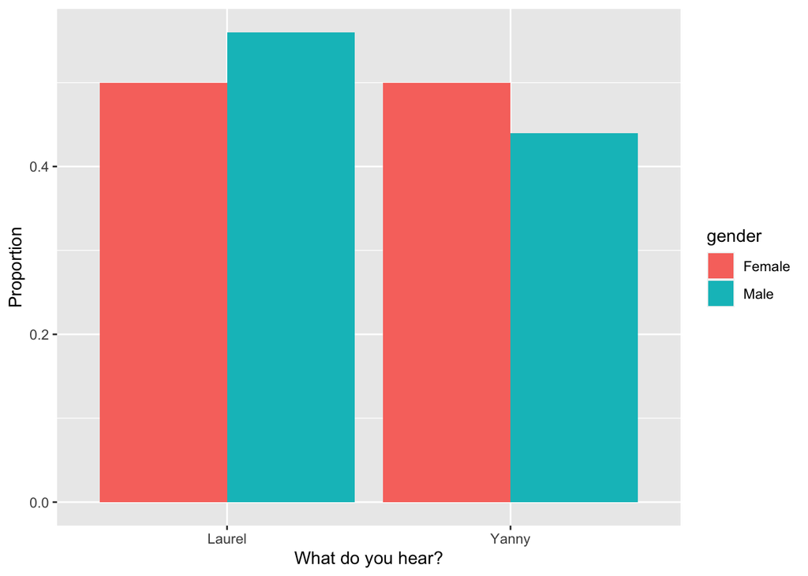

Barplot of what participants heard by gender.

```r
ggplot(data = yanny, aes(x = hear, group = gender)) +
  geom_bar(aes(y = ..prop.., fill = gender), stat = "count", position = "dodge") +
  labs(x = "What do you hear?", y = "Proportion")
```

There is a slightly smaller proportion of men hearing `Yanny`, but the proportions are very similar overall.

```r
mod.yanny <- logistic_reg()
mod.yanny <- mod.yanny |>
  fit(hear ~ age + gender, data = yanny) |>
  extract_fit_engine()

mod.yanny %>%
  summary()
```

```
Call:
stats::glm(formula = hear ~ age + gender, family = stats::binomial,
    data = data)

Deviance Residuals:
   Min      1Q  Median      3Q     Max
-1.381  -1.099  -0.776   1.154   1.809

Coefficients:
            Estimate Std. Error z value Pr(>|z|)
(Intercept)  1.62792    1.24392   1.309    0.191
age         -0.04839    0.03404  -1.422    0.155
genderMale  -0.20637    0.56935  -0.362    0.717

(Dispersion parameter for binomial family taken to be 1)

    Null deviance: 71.779  on 51  degrees of freedom
Residual deviance: 69.454  on 49  degrees of freedom
  (1 observation deleted due to missingness)
AIC: 75.454

Number of Fisher Scoring iterations: 4
```

```r
mod.yanny <- logistic_reg()
mod.yanny <- mod.yanny |> fit(hear ~ age, data = yanny) |>
  extract_fit_engine()

mod.yanny %>%
  summary()
```

```
Call:
stats::glm(formula = hear ~ age, family = stats::binomial, data = data)

Deviance Residuals:
    Min       1Q   Median       3Q      Max
-1.3566  -1.0881  -0.7971   1.1457   1.8505

Coefficients:
            Estimate Std. Error z value Pr(>|z|)
(Intercept)  1.51874    1.21032   1.255     0.21
age         -0.04812    0.03423  -1.406     0.16

(Dispersion parameter for binomial family taken to be 1)

    Null deviance: 71.779  on 51  degrees of freedom
Residual deviance: 69.586  on 50  degrees of freedom
  (1 observation deleted due to missingness)
AIC: 73.586

Number of Fisher Scoring iterations: 4
```

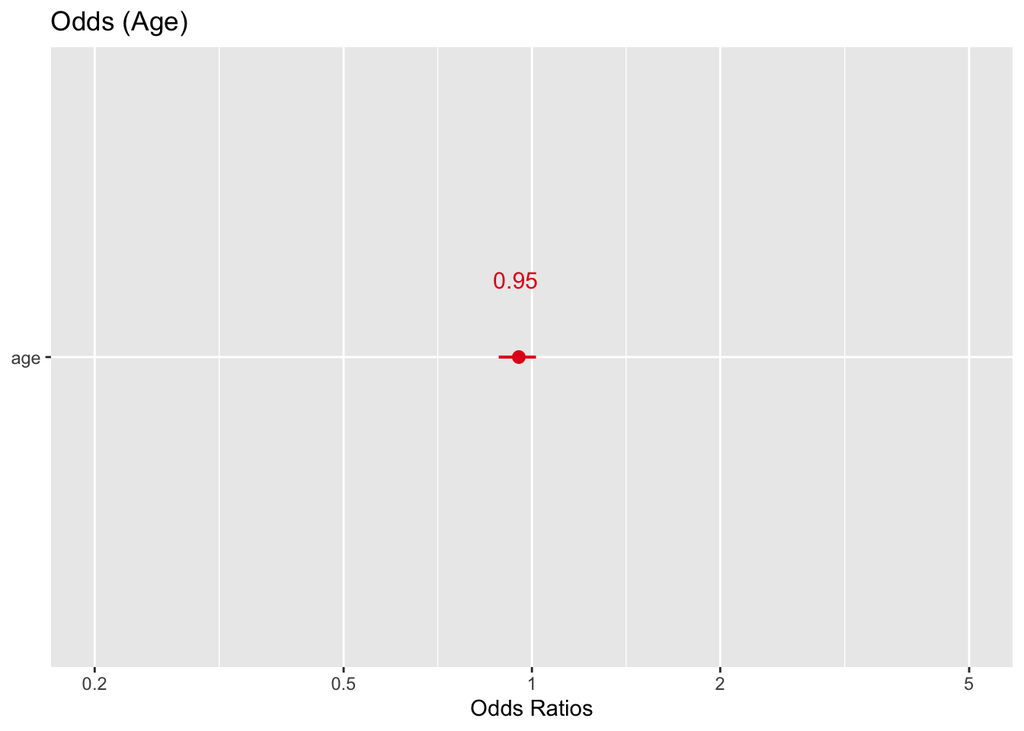

Odds of hearing yanny with age.

```r
plot_model(mod.yanny, show.values = TRUE,
           title = "Odds (Age)", show.p = TRUE)
```

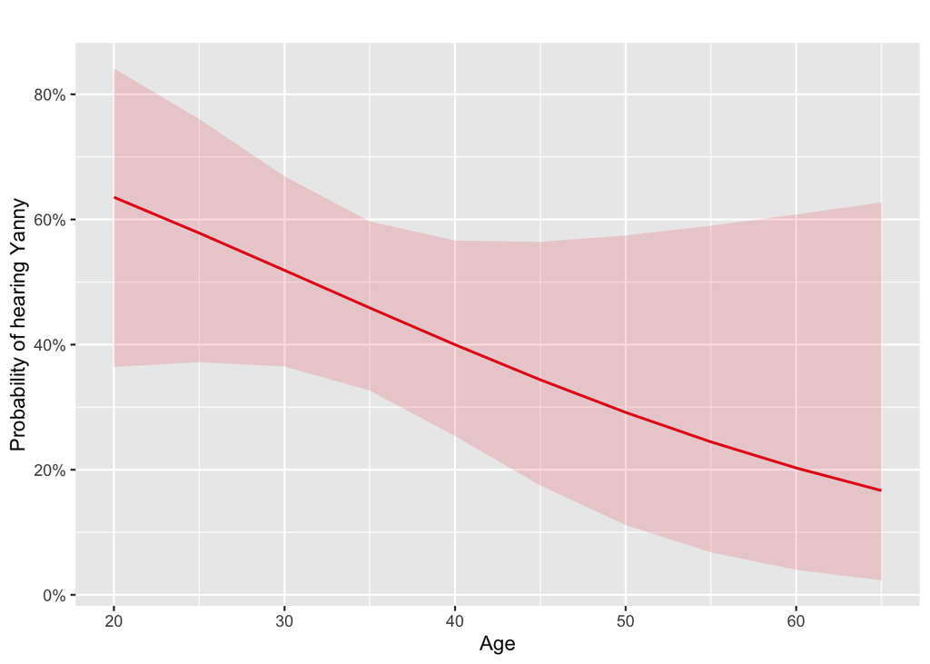

Probability of hearing Yanny with age.

```r
plot_model(mod.yanny, type = "pred", terms = "age", title = "", axis.title = c("Age", "Probability of hearing Yanny"))
```

## Titanic

On 15th April 1912, during its maiden voyage, the Titanic sank after colliding with an iceberg, killing 1502 out of 2224 passengers and crew. One of the reasons that the shipwreck led to such loss of life was that there were not enough lifeboats for the passengers and crew. Although there was some element of luck involved in surviving the sinking, some groups of people were more likely to survive than others, such as women, children, and the upper-class.

Download the data (`titanic.csv`) from Moodle for $n = 891$ passengers aboard the Titanic and fit a logistic regression model with `survived` as the binary response variable, and `age`, `gender`, and `passenger.class` as the explanatory variables. What are your findings?

**Solution**

```r
titanic <- read_csv("titanic.csv")
titanic <- titanic %>%
          select(survived, age, gender, passenger.class)
titanic$survived <- as.factor(titanic$survived)
levels(titanic$survived) <- c("Died", "Survived")
titanic$gender <- as.factor(titanic$gender)
titanic$passenger.class <- as.factor(titanic$passenger.class)
```

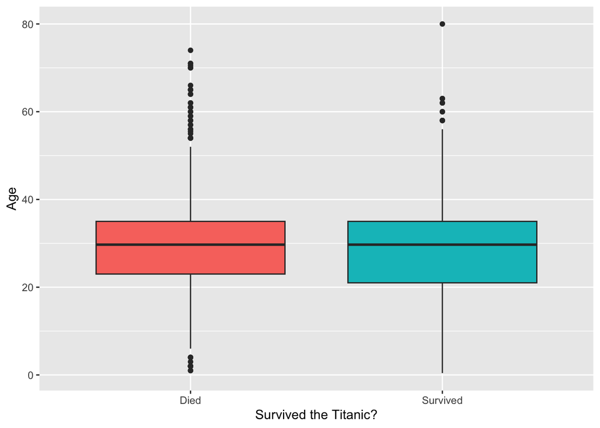

Titanic passenger age by survival.

```r
ggplot(data = titanic, aes(x = survived, y = age, fill = survived)) +
  geom_boxplot() +
  labs(x = "Survived the Titanic?", y = "Age") +
  theme(legend.position = "none")
```

We see in the boxplot that there is very little difference in the age of passengers who died or survived the sinking of the Titanic.

```r
titanic %>%
  tabyl(gender, survived) %>%
  adorn_percentages() %>%
  adorn_pct_formatting() %>%
  adorn_ns() # To show original counts
```

```
 gender        Died    Survived
 female 25.8%  (81) 74.2% (233)
   male 81.1% (468) 18.9% (109)
```

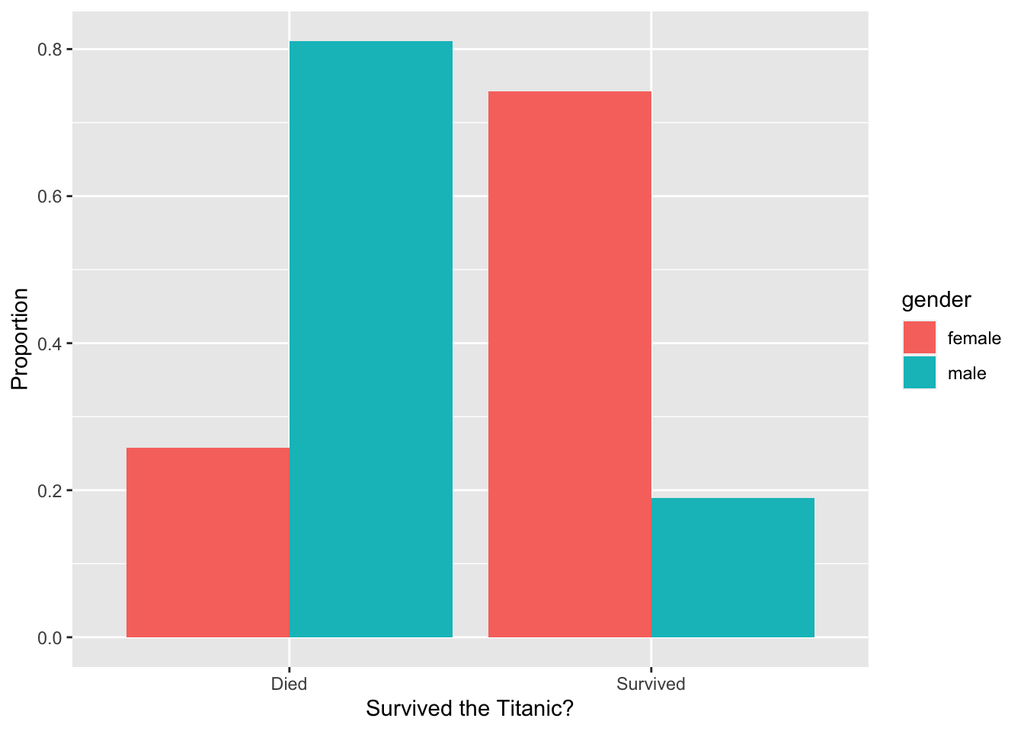

Barplot of passenger survival by gender.

```r
ggplot(data = titanic, aes(x = survived, group = gender)) +
  geom_bar(aes(y = ..prop.., fill = gender), stat = "count", position = "dodge") +
  labs(x = "Survived the Titanic?", y = "Proportion")
```

There is a clear pattern here with the proportion surviving much higher for females than for males.

```r
titanic %>%
  tabyl(passenger.class, survived) %>%
  adorn_percentages() %>%
  adorn_pct_formatting() %>%
  adorn_ns() # To show original counts
```

```
 passenger.class        Died    Survived
               1 37.0%  (80) 63.0% (136)
               2 52.7%  (97) 47.3%  (87)
               3 75.8% (372) 24.2% (119)
```

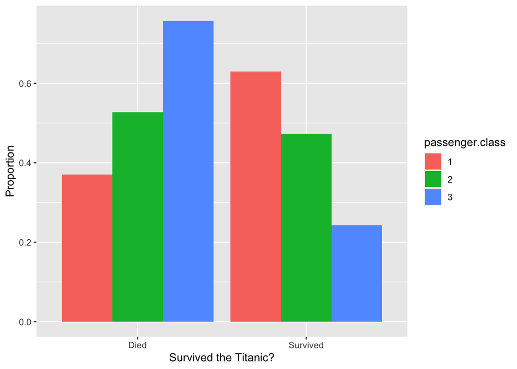

```r
ggplot(data = titanic, aes(x = survived, group = passenger.class)) +
  geom_bar(aes(y = ..prop.., fill = passenger.class),
            stat = "count", position = "dodge") +
  labs(x = "Survived the Titanic?", y = "Proportion")
```

The largest group of passengers who died were third class passengers, while among those who survived the largest group was first class passengers.

```r
mod.titanic <- logistic_reg()
mod.titanic <- mod.titanic |> fit (survived ~ gender + passenger.class + age, data = titanic) |>
  extract_fit_engine()
mod.titanic %>%
  summary()
```

```
Call:
stats::glm(formula = survived ~ gender + passenger.class + age,
    family = stats::binomial, data = data)

Deviance Residuals:
    Min       1Q   Median       3Q      Max
-2.6490  -0.6636  -0.4198   0.6328   2.4283

Coefficients:
                 Estimate Std. Error z value Pr(>|z|)
(Intercept)       3.54474    0.36537   9.702  < 2e-16 ***
gendermale       -2.61131    0.18671 -13.986  < 2e-16 ***
passenger.class2 -1.12216    0.25773  -4.354 1.34e-05 ***
passenger.class3 -2.32917    0.24089  -9.669  < 2e-16 ***
age              -0.03330    0.00737  -4.519 6.21e-06 ***
---
Signif. codes:  0 '***' 0.001 '**' 0.01 '*' 0.05 '.' 0.1 ' ' 1

(Dispersion parameter for binomial family taken to be 1)

    Null deviance: 1186.66  on 890  degrees of freedom
Residual deviance:  805.29  on 886  degrees of freedom
AIC: 815.29

Number of Fisher Scoring iterations: 5
```

We see that the coefficient for males (`gendermale`) is negative, indicating a lower chance of survival for male passengers. Similarly, the coefficients for second (`passenger.class2`) and third (`passenger.class3`) class passengers are negative, with the magnitude of the third class coefficient larger than that of the second class coefficient. This suggests that second class passengers chances of survival were worse in comparison with first class passengers, and that third class passengers chances of survival were even worse. Finally the `age` coefficient is negative, suggesting that older people were less likely to survive.

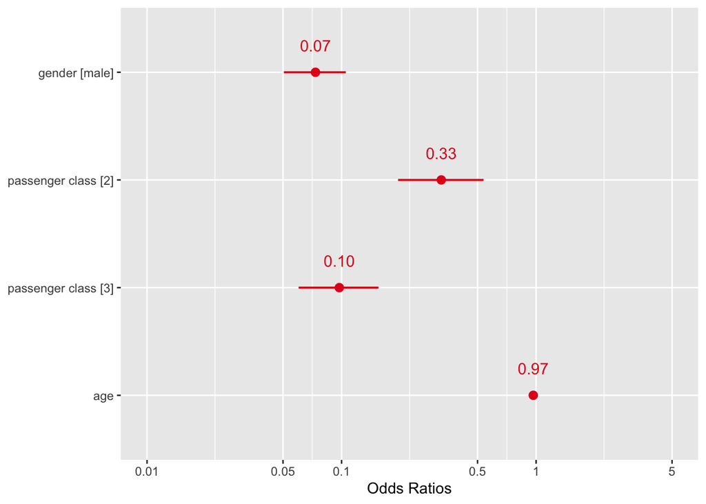

Odds of surviving the sinking of the Titanic.

```r
plot_model(mod.titanic, show.values = TRUE,
           title = "", show.p = FALSE, value.offset = 0.25)
```

We interpret the odds ratios as follows: men’s odds of survival were 0.07 times those of women, third class passengers’ odds of survival were 0.10 times those of first class passengers, and second class passengers’ odds of survival were 0.33 times those of first class passengers. Finally, for each year increase in the passenger’s age, their odds of survival decrease (by a factor of 0.97).